# Relatório 03 - Distribuição de probabilidade

Alex Gama

23/10/2024

# 1 Noções sobre conjuntos

## 1.1 Objetivos

• Compreender intuitivamente noções básicas relacionadas a conjuntos. • Conhecer alguns fatos da história da Teoria dos Conjuntos. • Revisar notações usadas no estudo dos conjunto.

### 1.1.1 Introdução

A compreensão de noções básicas sobre conjuntos é essencial para a Matemática. Para sermos mais enfáticos, hoje sabemos que todos os conceitos da Matemática moderna, desde os mais básicos, como o de números naturais, até os mais complexos, como o de variedades diferenciais, podem ser formulados na linguagem de conjuntos.

### 1.1.2 Idéia intuitiva de conjunto

Já deve estar claro que a noção de “conjunto” é uma noção fundamental da Matemática. Ela é a estrutura matemática sobre a qual todas as outras podem ser construídas (número, relação, função, …). O conceito de conjunto aparece em todos os ramos da Matemática e, a partir dele, podemos definir muitos outros conceitos matemáticos. Não definimos o que é um conjunto. Esse é um conceito primitivo. A ideia intuitiva que temos é a de que:

Um conjunto é qualquer coleção, lista ou classe de objetos bem definida. Os objetos de um conjunto podem ser qualquer coisa: números, pessoas, letras, rios, etc., e são chamados elementos ou membros do conjunto.

### 1.1.3 Conjuntos finitos e infinitos

Grosso modo, um conjunto é finito se consiste de um número específico de elementos diferentes, isto é, se, ao contarmos os seus diferentes membros, o processo de contagem chega a um final. De outro modo, o conjunto é infinito.

### 1.1.4 Conjuntos vazio, unitário e universal

• Conjunto vazio ou nulo é aquele que não contém elementos. Representamos um conjunto vazio por { } ou pelo símbolo ∅. São exemplos de conjuntos vazios:

Exemplo 1: A = {x | x é ímpar e múltiplo de 2} B = {x | x ≠ x}

• Conjunto unitário é aquele que só possui um elemento.

Exemplo 2: C = {x | 3x+1=7} = {2}

• Conjunto universal ou universo é conjunto de todos os elementos existentes em um determinado assunto em estudo. Dependendo do conjunto universo com que estamos trabalhando, um determinado problema pode ter uma ou outra solução, ou até não ter solução. Designaremos o conjunto universo por U.

Exemplo 3: Se procurarmos as soluções inteiras de certa equação, então o nosso conjunto universo é Z , conjunto de todos os números inteiros.

### 1.1.5 Igualdade de conjuntos

Um conjunto A é igual a um conjunto B, A = B, se ambos têm os mesmos elementos, isto é, se cada elemento pertencente a A pertencer também a B, e se cada elemento pertencente a B pertencer também a A. Simbolicamente: A = B ⇔ (∀x) (x∈A ⇔ x∈B).

### 1.1.6 Subconjuntos:Definições e teoremas

#### 1.1.6.1 Relação de inclusão e propriedades

Se cada elemento do conjunto A é também um elemento do conjunto B, dizemos que A é um subconjunto de B, ou que A está contido em B, ou que A é parte de B e indicamos por A ⊂ B. O símbolo ⊂ é denominado sinal de inclusão e a relação A ⊂ B chama-se relação de inclusão. Simbolicamente: A ⊂ B ⇔ (∀x) (x∈A ⇒ x∈B).

Propriedades da Inclusão

∅ ⊂ A, qualquer que seja o conjunto A.

1. A ⊂ A (reflexividade);
2. Se A ⊂ B e B ⊂ A, então A = B (antissimetria);
3. Se A ⊂ B e B ⊂ C, então A ⊂ C (transitividade).

# 2 Operações com conjuntos

## 2.1 Objetivos

• Realizar operações com conjuntos.

• Entender propriedades algébricas das operações com conjuntos.

• Relacionar a linguagem dos conjuntos com a linguagem da lógica.

### 2.1.1 Introdução

Na aritmética, podemos somar, multiplicar ou subtrair dois números quaisquer. Na Teoria dos Conjuntos, há três operações análogas: união, interseção, e complementação. Neste tópico, apresentaremos estas operações básicas com conjuntos.

### 2.1.2 União

Dados os conjuntos A e B, a reunião (ou união) de A e B é o conjunto, denotado por A ∪ B (que se lê “A união B”), constituído de todos os elementos que pertencem a A ou a B ou a ambos. Simbolicamente: A ∪ B = {x | x ∈ A ou x ∈ B}.

Exemplo 1:

{a, b, c} ∪ {c, d, e} = {a, b, c, d, e}

### 2.1.3 Interseção

Dados os conjuntos A e B, a interseção de A e B é o conjunto, denotado por A ∩ B (que se lê “A interseção B”), constituído de todos os elementos que pertencem ao mesmo tempo a A e a B. Simbolicamente:

A ∩ B = {x | x ∈ A e x ∈ B}.

Exemplo 2:

{a, b, c} ∩ {b, c, d, e} = {b, c}

Propriedades que relacionam a união e a interseção:

1. A ∪ (A ∩ B) = A
2. A ∩ (A ∪ B) = A
3. A ∪ (B ∩ C) = (A ∪ B) ∩ (A ∪ C) (distributiva da união em relação à interseção)
4. A ∩ (B ∪ C) = (A ∩ B) ∪ (A ∩ C) (distributiva da interseção em relação à união)

### 2.1.4 Diferença e complementação

Dados os conjuntos A e B, a diferença dos conjuntos A e B (ou, complemento de B em A) é o conjunto, denotado por A – B (que se lê “A diferença B” ou “A menos B”), constituído de todos os elementos que pertencem a A, mas não pertencem a B. Simbolicamente: A – B = {x | x ∈ A e x ∉ B}.

Exemplo 3: {a, b, c, d} – {c, d, e, f} = {a, b}

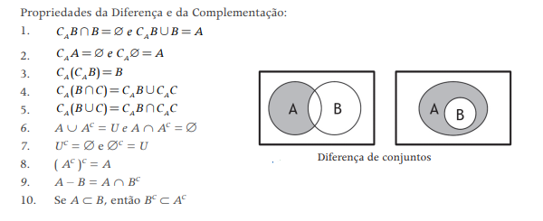

# 3 Probabilidade

## 3.1 Conceitos Básicos de Probabilidade

• Fenômeno Aleatório: É um processo de coleta de dados em que os resultados possíveis são conhecidos mas não se sabe qual deles ocorrerá. Assim, um fenômeno aleatório pode ser a contagem de ausências de um funcionário em um determinado mês, o resultado do lançamento de uma moeda, verificar o resultado de um exame de sangue, entre outros.

• Espaço Amostral: O conjunto de todos os resultados possíveis do fenômeno aleatório é chamado de espaço amostral. Vamos representá-lo por Ω.

Exemplos:

Lançamento de uma moeda. Ω = {cara, coroa}.

Lançamento de um dado. Ω = {1, 2, 3, 4, 5, 6}.

Número de chips defeituosos em uma linha de produção durante 24 horas. Ω = {0, 1, 2, 3, . . . , n}, sendo n o número máximo de itens defeituosos.

Tempo de reação de uma pomada anestésica aplicada em queimados. Ω = {t ∈ ℜ | t≥ 0 }.

• Evento: Qualquer subconjunto do espaço amostral Ω é chamado de evento. Serão representados por letras maiúsculas A, B, . . . . Dentre os eventos podemos considerar o evento união de A e B, denotado por A ∪ B, que, equivale à ocorrência de A, ou de B, ou de ambos. A ocorrência simultânea dos eventos A e B, denotada por A ∩ B é chamada de evento interseção. Dois eventos A e B dizem-se mutuamente exclusivos ou disjuntos,quando a ocorrência de um deles impossibilita a ocorrência do outro. Os dois eventos não têm nenhum elemento em comum, isto é, A ∩ B = ∅ (conjunto vazio).

Exemplos:

## 3.2 Definição clássica de probabilidade

Em fenômenos aleatórios tais como lançamento de uma moeda, de um dado, extração de uma carta de um baralho entre outros, temos que todos os resultados possíveis tem a mesma chance de ocorrer. Assim, por exemplo no lançamento de uma moeda a probabilidade do evento cara ou coroa ocorrer são igualmente prováveis, ou seja, a probabilidade atribuída a cada um é 1/2. A probabilidade de um evento A qualquer ocorrer pode ser definida por:

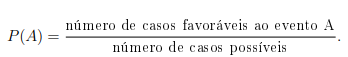

## 3.3 Propriedades de probabilidades

É uma função P(.) que associa números reais aos elementos do espaço amostral e satisfaz as condições:

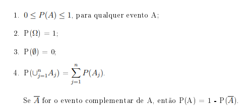

## 3.4 Teorema da soma

Dado dois eventos A e B, a probabilidade de pelo menos um deles ocorrer é igual a soma das probabilidades de cada um menos a probabilidade de ambos ocorrerem simultaneamente, ou seja:

P(A ∪ B) = P(A) + P(B) − P(A ∩ B).

Se A e B forem mutuamente exclusivos, teremos P(A∩B) = 0.

Assim,P(A ∪ B) = P(A) + P(B).

Exemplo: Considere o experimento lançamento de um dado e os seguintes eventos:

A = {sair número 5},

B = {sair número par} e

C = {sair número ímpar}.

Determinar: Ω, P(A), P(B), P(C), P(A∪B), P(A∪C) e P(A).

Ω = {1, 2, 3, 4, 5, 6}.

P(A) = 1/6

P(B) = 3/6

P(C) = 3/6

P(A ∪ B) = 1/6 + 3/6 = 4/6

P(A ∪ C) = 1/6 + 2/6 = 3/6

## 3.5 Probabilidade condicional

Exemplo: Em uma universidade foi selecionada uma amostra de 500 alunos que cursaram a disciplina de Estatística. Entre as questões levantadas estava: Você gostou da disciplina de Estatística? De 240 homens, 140 responderam que sim. De 260 mulheres, 200 responderam que sim. Para avaliar as probabilidades podemos organizar as informações em uma tabela. maneira:

Qual é a probabilidade de que um aluno escolhido aleatoriamente:

1. H = Seja um homem?

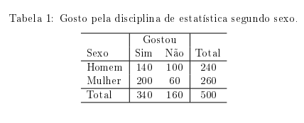

2. G = Gostou da disciplina de Estatística?
3. M = Seja uma mulher?
4. NG = Não gostou da disciplina de Estatística?
5. Seja uma mulher ou gostou da disciplina de Estatística.

(f ) Seja uma mulher e gostou da disciplina de Estatística.

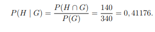

8. Dado que o aluno escolhido é uma mulher. Qual a probabilidade de que ela não gostou da disciplina de Estatística?

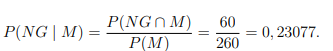

## 3.6 Teorema do produto

Da definição de probabilidade condicional P(A|B) = P(A∩B)/P(B),podemos obter o teorema do produto, que nos permite calcular a probabilidade da ocorrência simultânea de dois eventos.

Sejam A e B eventos de Ω, a probabilidade de A e B ocorrerem juntos é dada por:

P(A ∩ B) = P(A).P(B|A), com P(A) > 0 ou P(A ∩ B) = P(B).P(A|B), com P(B) > 0.

Dois eventos A e B são independentes quando a ocorrência de um não altera a probabilidade de ocorrência do outro. Desse modo,P(A ∩ B) = P(A).P(B).

Exemplo:Uma empresária sabe por experiência, que 65% das mulheres que compram em sua loja preferem sandálias plataformas. Qual é a probabilidade de as duas próximas clientes comprarem cada uma delas, uma sandália plataforma? Vamos admitir que o evento A é a primeira cliente compra uma sandália plataforma e o evento B é a segunda cliente compra uma sandália plataforma. Então,

P(A ∩ B) = (0,65)(0,65) = 0,4225.